# SSVEP reward - EEG results

Ivan Grahek & Antonio Schettino

2019-07-03

## About the code

Experiment: FSAReward (Ivan Grahek*, Antonio Schettino*, Gilles Pourtois, Ernst Koster, & Søren Andersen) (*: co-first authors) Code written by: Ivan Grahek & Antonio Schettino (2016-2018) Description: Code for the analysis of EEG data for Experiment 1 of the SSVEP - reward project.

## Topography & spectra

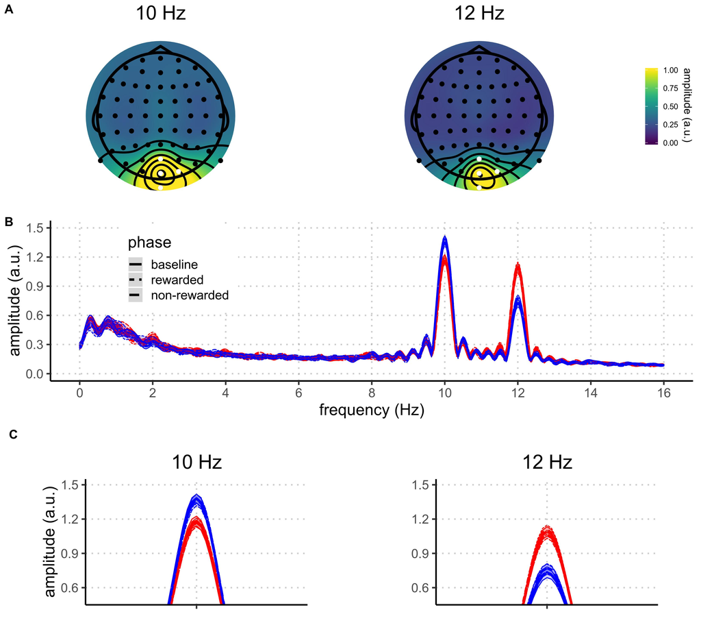

```r
# # Clear environemnt and import data------------------------------------------------------------------------------------------------------------------------------------------------------------------------------------------------------

# clear the environment
rm(list=ls())
# clear the console
cat("\014")
```

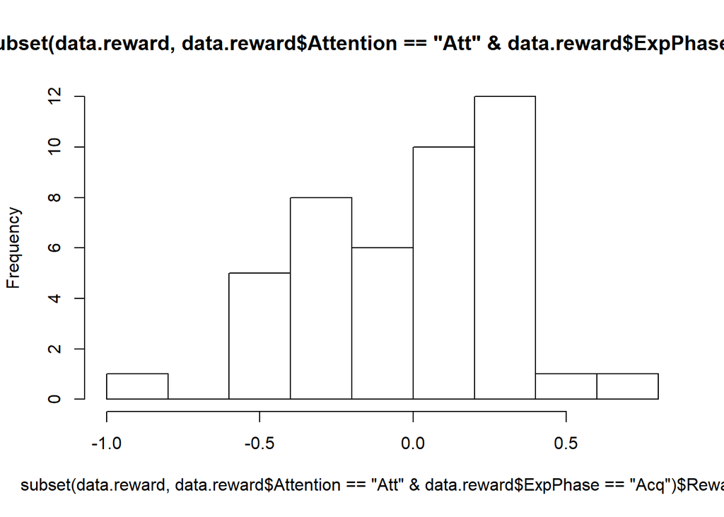

```r
#load packages and install them if they're not installed
if (!require("pacman")) install.packages("pacman")
pacman::p_load(reshape2,yarrr,BayesFactor,plyr,ez,schoRsch,brms,knitr,broom, brmstools, BEST, tidyverse, here)
# set seed
set.seed(42)
# Set working directory
#setwd(here())
# import data
data.raw = read.csv(file = here("EEG_preprocessing/movement","grandAverage_amplitudes.csv"),header=TRUE,na.strings="NaN")


# Prepare the dataset------------------------------------------------------------------------------------------------------------------------------------------------------------------------------------------------------

# # Average the movement and no movement trials
# data.raw = ddply(data.raw,.(Subject,Frequency),transform,
#              BslnRedAttended = (BslnRedAttended + BslnRedAttendedMovement)/2,
#              BslnBlueAttended = (BslnBlueAttended + BslnBlueAttendedMovement)/2,
#              AcqRedAttended = (AcqRedAttended + AcqRedAttendedMovement)/2,
#              AcqBlueAttended = (AcqBlueAttended + AcqBlueAttendedMovement)/2,
#              ExtRedAttended = (ExtRedAttended + ExtRedAttendedMovement)/2,
#              ExtBlueAttended = (ExtBlueAttended + ExtBlueAttendedMovement)/2)



# Select only movement or no movement trials

# Only no movement
#
# data.raw = select(data.raw,"Subject","Frequency","BslnRedAttended","BslnBlueAttended","AcqRedAttended","AcqBlueAttended","ExtRedAttended","ExtBlueAttended")

# Rename columns
colnames(data.raw) = c("Subject","Frequency","BslnRedAttendedNomov","BslnBlueAttendedNomov","AcqRedAttendedNomov","AcqBlueAttendedNomov","ExtRedAttendedNomov","ExtBlueAttendedNomov","BslnRedAttendedMov","BslnBlueAttendedMov","AcqRedAttendedMov","AcqBlueAttendedMov","ExtRedAttendedMov","ExtBlueAttendedMov")

# # Reshape to long format - take only no movement trials
data = melt(data.raw,id.vars=c("Subject","Frequency"),
            measure.vars=c("BslnRedAttendedNomov","BslnBlueAttendedNomov","AcqRedAttendedNomov","AcqBlueAttendedNomov","ExtRedAttendedNomov","ExtBlueAttendedNomov","BslnRedAttendedMov","BslnBlueAttendedMov","AcqRedAttendedMov","AcqBlueAttendedMov","ExtRedAttendedMov","ExtBlueAttendedMov"),
            variable.name="Condition",value.name="Amplitude")

# Reshape to long format - take only movement trials
# data = melt(data.raw,id.vars=c("Subject","Frequency"),
#             measure.vars=c("BslnRedAttendedMov","BslnBlueAttendedMov","AcqRedAttendedMov","AcqBlueAttendedMov","ExtRedAttendedMov","ExtBlueAttendedMov"),
#             variable.name="Condition",value.name="Amplitude")

# Sort the new dataframe by participant name
data = data[order(data$Subject),]

# Split the variable Condition based on capital letters
data$Condition = gsub("(?!^)(?=[[:upper:]])", " ", data$Condition, perl=T)

# Split the variable condition into multiple variables
Conditions = colsplit(data$Condition, pattern="\\s+",names = c('ExpPhase', 'ColorMoved',"attended","no","moved"))

# Add the variable defining which color is rewarded based on the participant number
data$RewardedColor = ifelse(data$Subject%%2==0,"Blue","Red") # if participant number is even, blue was rewarded

# Add the Conditions needed to the dataset
data$ExpPhase = Conditions[,1]
data$AttendedColor = Conditions[,2]
data$Movement = Conditions[,4]

# Switch the Frequency to the color
data$RecordedFrequency = ifelse(data$Frequency==10,"Blue","Red") # if the recorded frequency is 10Hz assign Blue (color flickering at 10Hz), otherwise assign Red (color flickering at 12Hz)

# Make a new condition based on the attended color and the rewarded color
data$Condition = ifelse(data$AttendedColor==data$RewardedColor, "High_Rew","Low_Rew")

# Make a new condition based on the attended color and the recorded frequency
data$Attention = ifelse(data$AttendedColor==data$RecordedFrequency, "Att","NotAtt")

# Make a new condition based the Condition and the Attention
data$RecordingAndCondition = with(data, paste0(Condition,"_",Attention))

# Select variables which we want to keep
data = subset(data, select=c("Subject","RewardedColor","ExpPhase","AttendedColor","Condition","RecordedFrequency","Attention","RecordingAndCondition","Movement","Amplitude"))

# Take only the movement trials
data = subset(data, Movement=="Nomov")


# Sort the data
data = data[with(data, order(Subject)), ]

# Normalize the two frequencies
# Make a new variable with mean amplitude across all conditions for each participant and each frequency  !!! originally did not include ExpPhase below !!!
# data = ddply(data,.(Subject,RecordedFrequency),transform,
#                     MeanAmplitude = mean(Amplitude,na.rm=TRUE),
#                     SDAmplitude =   sd(Amplitude,na.rm=TRUE))

# Make a new variable with mean amplitude across all conditions for each participant and each frequency
data = ddply(data,.(Subject,RecordedFrequency),transform,
             MeanAmplitude = mean(Amplitude[ExpPhase=="Bsln"],na.rm=TRUE),
             SDAmplitude =   sd(Amplitude,na.rm=TRUE))

#MeanAmplitude = mean(Amplitude[ExpPhase=="Bsln"],na.rm=TRUE),   [ExpPhase=="Bsln"]

# Divide amplitudes in each Subject, Frequency, and Condition by the Mean Amplitude
data$Amplitude = data$Amplitude/data$MeanAmplitude

# Calculate the attention indexes - Selectivity (attended-unattended) & total enhancement (attended+unattended) (Andersen & Muller, 2010, PNAS)
data.diff = ddply(data, .(Subject,ExpPhase,Condition), transform, Selectivity = Amplitude[Attention=="Att"]-Amplitude[Attention=="NotAtt"],TotalEnhancement=Amplitude[Attention=="Att"]+Amplitude[Attention=="NotAtt"])
# Delete the Attention column and rows which are not necessary (indexes repeated twice)
data.diff = subset(data.diff,Attention=="Att") #keep only Att as it is equal to NotAtt
data.diff$Attention = NULL  #drop the Attention column

# Sort the data
data.diff$ExpPhase = factor(data.diff$ExpPhase, levels = c("Bsln","Acq","Ext"))
data.diff = data.diff[order(data.diff$Subject,data.diff$Condition,data.diff$ExpPhase),]

# Calculate the reward index - High reward minus Low reward
data.reward = ddply(data, .(Subject,ExpPhase,Attention), transform, Reward = Amplitude[Condition=="High_Rew"]-Amplitude[Condition=="Low_Rew"])
# Delete the Attention column and rows which are not necessary (indexes repeated twice)
data.reward = subset(data.reward,Condition=="High_Rew") #keep only Att as it is equal to NotAtt
data.reward$Condition = NULL  #drop the Condition column

# Sort the data
data.reward$ExpPhase = factor(data.reward$ExpPhase, levels = c("Bsln","Acq","Ext"))
data.reward = data.reward[order(data.reward$Subject,data.reward$Attention,data.reward$ExpPhase),]

hist(subset(data.reward,data.reward$Attention=="Att" & data.reward$ExpPhase=="Acq" )$Reward)
```

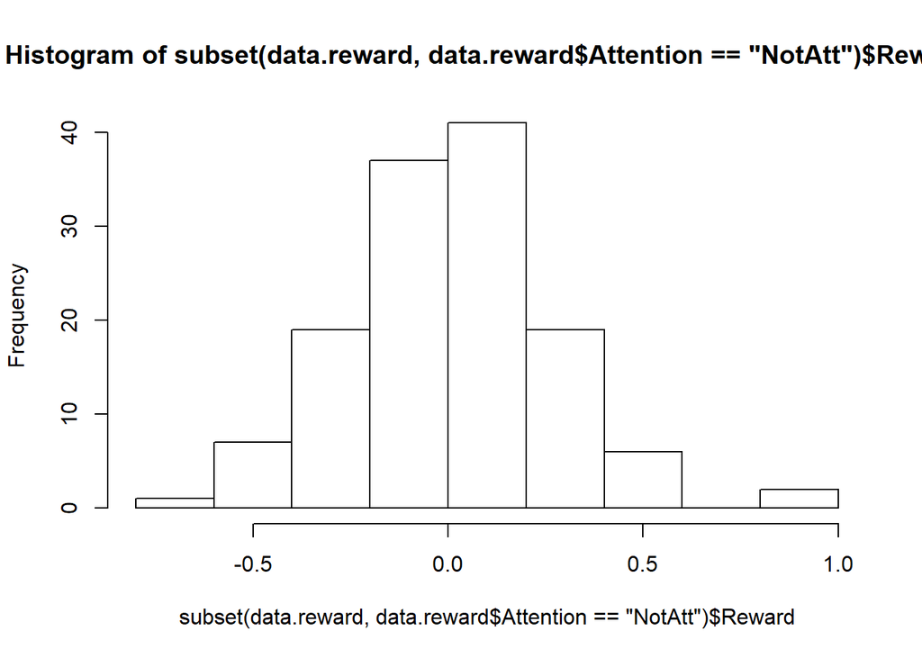

```r
hist(subset(data.reward,data.reward$Attention=="NotAtt")$Reward)
```

```r
# Convert variables to be used in analyses into factors
data[c("Subject", "Condition","ExpPhase", "RewardedColor", "Attention", "RecordingAndCondition")] =
  lapply(data[c("Subject", "Condition","ExpPhase", "RewardedColor", "Attention", "RecordingAndCondition")], factor)

data.diff[c("Subject", "Condition","ExpPhase", "RecordingAndCondition")] =
  lapply(data.diff[c("Subject", "Condition","ExpPhase",  "RecordingAndCondition")], factor)
```

## Means - raw data

```r
summary = ddply(data,.(Attention,ExpPhase,Condition),plyr::summarize,Mean=c(paste(round(mean(Amplitude, na.rm = TRUE), digits = 2), " [", round(hdi(Amplitude)[[1]], digits = 2), " ", round(hdi(Amplitude)[[2]], digits = 2), "]")))

names(summary) = c("Attention", "Reward phase", "Reward probability", "Amplitude")

summary$Attention = recode(summary$Attention,
                           "Att" = "Attended",
                           "NotAtt" = "Unattended")

summary$`Reward phase` = recode(summary$`Reward phase`,
                           "Acq" = "Acquisition",
                           "Bsln" = "Baseline",
                           "Ext" = "Extinction")

summary$`Reward probability` = recode(summary$`Reward probability`,
                           "High_Rew" = "High",
                           "Low_Rew" = "Low")

summary = as.data.frame(summary)

summary$`Reward phase` = factor(summary$`Reward phase`, levels = c("Baseline","Acquisition","Extinction"))
summary = summary[order(summary$Attention,summary$`Reward phase`,summary$`Reward probability`),]
row.names(summary) = NULL

kable(summary, caption = "Amplitudes per condition")
```

Amplitudes per condition

| Attention | Reward phase | Reward probability | Amplitude |
| --- | --- | --- | --- |
| Attended | Baseline | High | 1.14 [ 0.94 1.41 ] |
| Attended | Baseline | Low | 1.13 [ 0.92 1.5 ] |
| Attended | Acquisition | High | 1.15 [ 0.81 1.47 ] |
| Attended | Acquisition | Low | 1.15 [ 0.59 1.54 ] |
| Attended | Extinction | High | 1.12 [ 0.63 1.54 ] |
| Attended | Extinction | Low | 1.15 [ 0.77 2.04 ] |
| Unattended | Baseline | High | 0.87 [ 0.5 1.08 ] |
| Unattended | Baseline | Low | 0.86 [ 0.59 1.06 ] |
| Unattended | Acquisition | High | 0.93 [ 0.56 1.44 ] |
| Unattended | Acquisition | Low | 0.89 [ 0.62 1.3 ] |
| Unattended | Extinction | High | 0.89 [ 0.45 1.19 ] |
| Unattended | Extinction | Low | 0.9 [ 0.54 1.39 ] |

## Plots - raw data

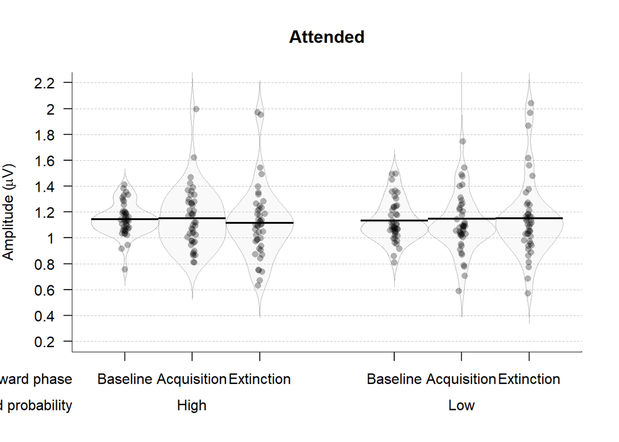

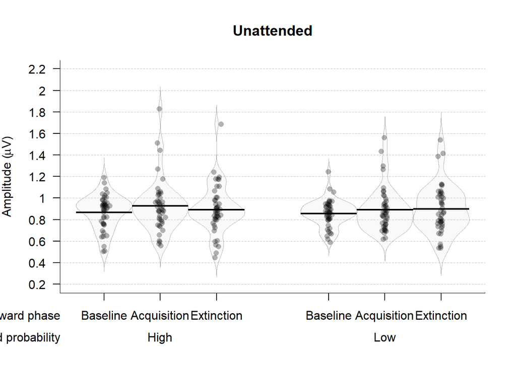

```r
# Plot amplitude across experiment phases------------------------------------------------------------------------------------------------------------------------------------------------------------------------------------------------------
# prepare data for plotting
dataPlot = data

# rename variables
colnames(dataPlot)[colnames(dataPlot)=="ExpPhase"] <- "Reward phase"
colnames(dataPlot)[colnames(dataPlot)=="Condition"] <- "Reward probability"

# rename conditions
dataPlot$`Reward phase` = recode(dataPlot$`Reward phase`,
                                  "Acq" = "Acquisition",
                                  "Bsln" = "Baseline",
                                  "Ext" = "Extinction")

dataPlot$`Reward probability` = recode(dataPlot$`Reward probability`,
                                        "High_Rew" = "High",
                                        "Low_Rew" = "Low")

#order
dataPlot$`Reward phase` = factor(dataPlot$`Reward phase`, levels = c("Baseline","Acquisition","Extinction"))
dataPlot = dataPlot[order(dataPlot$Attention,dataPlot$`Reward phase`,dataPlot$`Reward probability`),]


plottingConditions = c("Attended","Unattended" )
for (i in 1:length(plottingConditions)){

  if(plottingConditions[i]=="Attended"){dataAmplitudePlot=subset(dataPlot,Attention=="Att")}

  if(plottingConditions[i]=="Unattended"){dataAmplitudePlot=subset(dataPlot,Attention=="NotAtt")}

# Pirate plot

    pirateplot(formula = Amplitude ~ `Reward phase` + `Reward probability`, # dependent~independent variables
             data=dataAmplitudePlot, # data frame
             main=plottingConditions[i], # main title
             ylim=c(0.2,2.2), # y-axis: limits
             ylab=expression(paste("Amplitude (",mu,"V)")), # y-axis: label
             theme=0, # preset theme (0: use your own)
             point.col="black", # points: color
             point.o=.3, # points: opacity (0-1)
             avg.line.col="black", # average line: color
             avg.line.lwd=2, # average line: line width
             avg.line.o=1, # average line: opacity (0-1)
             bean.b.col="black", # bean border, color
             bean.lwd=0.6, # bean border, line width
             bean.lty=1, # bean border, line type (1: solid; 2:dashed; 3: dotted; ...)
             bean.b.o=0.3, # bean border, opacity (0-1)
             bean.f.col="gray", # bean filling, color
             bean.f.o=.1, # bean filling, opacity (0-1)
             cap.beans=FALSE, # max and min values of bean densities are capped at the limits found in the data
             gl.col="gray", # gridlines: color
             gl.lty=2, # gridlines: line type (1: solid; 2:dashed; 3: dotted; ...)
             cex.lab=1, # axis labels: size
             cex.axis=1, # axis numbers: size
             cex.names = 1,
             bty="l", # plot box type
             back.col="white") # background, color
}
```

## Statistics

```r
# Set the working directory in order to load the models
# Set working directory
setwd(here("brms_models"))

# # Set the intercept model
# data$ExpPhase=relevel(data$ExpPhase,ref="Bsln")
# data$Condition=relevel(data$Condition,ref="High_Rew")
# data$Attention=relevel(data$Attention,ref="Att")
#
#
# # Null model
# null = brm(Amplitude ~ 1 + (1|Subject),
#                               data=data,
#                               family=gaussian(),
#                               warmup = 2000,
#                               iter = 10000,
#                               save_all_pars = TRUE,
#                               control = list(adapt_delta = 0.99),
#                               cores = 4,
#                               sample_prior = TRUE)
# saveRDS(null,file="null.EEG.allsub.rds")
#
# # Exp phase model
# expphase = brm(Amplitude ~ ExpPhase + (ExpPhase|Subject),
#                                   data=data,
#                                   family=gaussian(),
#                                   warmup = 2000,
#                                   iter = 10000,
#                                   save_all_pars = TRUE,
#                                   control = list(adapt_delta = 0.99),
#                                   cores = 4,
#                                   sample_prior = TRUE)
# saveRDS(expphase,file="expphase.EEG.allsubs.rds")
#
# # Attention model
# attention = brm(Amplitude ~ Attention + (Attention|Subject),
#                                    data=data,
#                                    family=gaussian(),
#                                    warmup = 2000,
#                                    iter = 10000,
#                                    save_all_pars = TRUE,
#                                    control = list(adapt_delta = 0.99),
#                                    cores = 4,
#                                    sample_prior = TRUE)
# saveRDS(attention,file="attention.EEG.allsubs.rds")
#
# # Two main effects - phase and attention
# phaseANDattention = brm(Amplitude ~ ExpPhase + Attention + (ExpPhase + Attention|Subject),
#                                         data=data,
#                                         family=gaussian(),
#                                         warmup = 2000,
#                                         iter = 10000,
#                                         save_all_pars = TRUE,
#                                         control = list(adapt_delta = 0.99),
#                                         cores = 4,
#                                         sample_prior = TRUE)
# saveRDS(phaseANDattention,file="phaseANDattention.EEG.allsubs.rds")
#
# # Interaction between expphase and reward magnitude plus attention
# rewardTimesPhasePlusAtt = brm(Amplitude ~ Condition * ExpPhase + Attention + (Condition * ExpPhase + Attention|Subject),
#                          data=data,
#                          family=gaussian(),
#                          warmup = 2000,
#                          iter = 10000,
#                          save_all_pars = TRUE,
#                          control = list(adapt_delta = 0.99),
#                          cores = 4,
#                          sample_prior = TRUE)
# saveRDS(rewardTimesPhasePlusAtt,file="rewardTimesPhasePlusAtt.EEG.allsubs.rds")
#
# # Full model
# full = brm(Amplitude ~ Condition * ExpPhase * Attention + (Condition * ExpPhase * Attention|Subject),
#                               data=data,
#                               family=gaussian(),
#                               warmup = 2000,
#                               iter = 10000,
#                               save_all_pars = TRUE,
#                               control = list(adapt_delta = 0.99),
#                               cores = 4,
#                               sample_prior = TRUE)
# saveRDS(full,file="full.EEG.allsubs.rds")
#
# #Trial
# #full = brm(Amplitude ~ Condition * ExpPhase * Attention + (Condition * ExpPhase * Attention|Subject/Trial),
#
# # read in the models and comparisons
# null = readRDS("null.EEG.allsub.rds")
# attention = readRDS("attention.EEG.allsubs.rds")
# expphase = readRDS("expphase.EEG.allsubs.rds")
# phaseANDattention = readRDS("phaseANDattention.EEG.allsubs.rds")
# rewardTimesPhasePlusAtt = readRDS("rewardTimesPhasePlusAtt.EEG.allsubs.rds")
# full = readRDS("full.EEG.allsubs.rds")
# # waic = readRDS("compare.EEG.waic.allsubs.rds")
#
# # color_scheme_set("viridis")
# # pp_check(full, type = "stat_grouped", nsamples = 100, group = "ExpPhase")
#
# # WAIC
# compare.EEG.waic = WAIC(null, expphase, attention, phaseANDattention, rewardTimesPhasePlusAtt, full, compare = TRUE)
# saveRDS(compare.EEG.waic,file="compare.EEG.waic.allsubs.rds")
#
# # Weighted waic
# compare.EEG.waic.weights = model_weights(null, expphase, attention, phaseANDattention, rewardTimesPhasePlusAtt, full, weights = "waic")
# saveRDS(compare.EEG.waic.weights,file="compare.EEG.waic.weights")
#
# # Bayesian R2
# #Null
# bR2.null.EEG = bayes_R2(null)
# saveRDS(bR2.null.EEG,file="bR2.null.EEG")
# #ExpPhase
# bR2.expphase.EEG = bayes_R2(expphase)
# saveRDS(bR2.expphase.EEG,file="bR2.expphase.EEG")
# #Phase and attention
# bR2.phaseANDattention.EEG = bayes_R2(phaseANDattention)
# saveRDS(bR2.phaseANDattention.EEG,file="bR2.phaseANDattention.EEG")
# #Reward times phase plus attention
# bR2.rewardTimesPhasePlusAtt.EEG = bayes_R2(rewardTimesPhasePlusAtt)
# saveRDS(bR2.rewardTimesPhasePlusAtt.EEG,file="bR2.rewardTimesPhasePlusAtt.EEG")
# #Full
# bR2.full.EEG = bayes_R2(model.full.EEG)
# saveRDS(bR2.full.EEG,file="bR2.full.EEG")


# read in the models and comparisons
# null = readRDS("null.EEG.allsub.rds")
# attention = readRDS("attention.EEG.allsubs.rds")
# expphase = readRDS("expphase.EEG.allsubs.rds")
# phaseANDattention = readRDS("phaseANDattention.EEG.allsubs.rds")
# rewardTimesPhasePlusAtt = readRDS("rewardTimesPhasePlusAtt.EEG.allsubs.rds")
model.full.threefactors = readRDS("full.EEG.allsubs.rds")
compare.threefactors.EEG.waic = readRDS("compare.EEG.waic.allsubs.rds")
compare.EEG.waic.weights = readRDS("compare.EEG.waic.weights")
bR2.null.EEG = readRDS("bR2.null.EEG")
bR2.expphase.EEG = readRDS("bR2.expphase.EEG")
bR2.attention.EEG = readRDS("bR2.attention.EEG")
bR2.phaseANDattention.EEG = readRDS("bR2.phaseANDattention.EEG")
bR2.phaseANDattention_interaction.EEG = readRDS("bR2.phaseANDattention_interaction.EEG")
bR2.rewardTimesPhasePlusAtt.EEG = readRDS("bR2.rewardTimesPhasePlusAtt.EEG")
bR2.full.EEG = readRDS("bR2.full.EEG")
```

### Model comparison with WAIC

```r
print(compare.threefactors.EEG.waic)
```

```
##                                                            WAIC    SE
## null                                                      64.25 52.97
## expphase                                                  39.35 46.41
## attention                                               -118.80 56.88
## phaseANDattention                                       -172.79 49.16
## phaseANDattention_interaction                           -170.17 49.66
## rewardTimesPhasePlusAtt                                 -239.40 57.58
## full                                                    -232.28 57.49
## null - expphase                                           24.91 15.90
## null - attention                                         183.05 27.00
## null - phaseANDattention                                 237.05 32.06
## null - phaseANDattention_interaction                     234.43 31.26
## null - rewardTimesPhasePlusAtt                           303.65 34.56
## null - full                                              296.54 34.21
## expphase - attention                                     158.15 31.61
## expphase - phaseANDattention                             212.14 26.01
## expphase - phaseANDattention_interaction                 209.52 25.29
## expphase - rewardTimesPhasePlusAtt                       278.75 31.70
## expphase - full                                          271.63 31.14
## attention - phaseANDattention                             53.99 24.48
## attention - phaseANDattention_interaction                 51.37 23.94
## attention - rewardTimesPhasePlusAtt                      120.60 27.24
## attention - full                                         113.48 27.39
## phaseANDattention - phaseANDattention_interaction         -2.62  2.54
## phaseANDattention - rewardTimesPhasePlusAtt               66.61 19.97
## phaseANDattention - full                                  59.49 20.18
## phaseANDattention_interaction - rewardTimesPhasePlusAtt   69.23 19.85
## phaseANDattention_interaction - full                      62.11 19.80
## rewardTimesPhasePlusAtt - full                            -7.11  3.63
```

### Model comparison with WAIC weights

```r
print(compare.EEG.waic.weights)
```

```
##                          null                      expphase
##                  1.786409e-39                  6.315656e-41
##                     attention             phaseANDattention
##                  3.683329e-20                  1.707100e-22
## phaseANDattention_interaction       rewardTimesPhasePlusAtt
##                  4.440203e-24                  6.740999e-07
##                          full
##                  9.999993e-01
```

### Bayesian R squared

Null model

```r
print(bR2.null.EEG)
```

```
##      Estimate  Est.Error       Q2.5     Q97.5
## R2 0.08553042 0.02962467 0.03039593 0.1456651
```

Experiment phase

```r
print(bR2.expphase.EEG)
```

```
##     Estimate  Est.Error      Q2.5     Q97.5
## R2 0.1758689 0.03303595 0.1113223 0.2393681
```

Attention model

```r
print(bR2.attention.EEG)
```

```
##     Estimate  Est.Error      Q2.5    Q97.5
## R2 0.4209405 0.03126692 0.3568082 0.478425
```

Phase and attention model

```r
print(bR2.phaseANDattention.EEG)
```

```
##     Estimate  Est.Error      Q2.5   Q97.5
## R2 0.5121814 0.02749291 0.4542854 0.56168
```

Phase and attention interaction model

```r
print(bR2.phaseANDattention_interaction.EEG)
```

```
##     Estimate  Est.Error      Q2.5     Q97.5
## R2 0.5138107 0.02737659 0.4563496 0.5635469
```

Reward times phase plus attention model

```r
print(bR2.rewardTimesPhasePlusAtt.EEG)
```

```
##     Estimate  Est.Error      Q2.5    Q97.5
## R2 0.6156175 0.02380128 0.5646034 0.658192
```

Full model

```r
print(bR2.full.EEG)
```

```
##     Estimate  Est.Error      Q2.5    Q97.5
## R2 0.6170324 0.02400106 0.5669053 0.659541
```

### Checking the best model

Plotting the chains

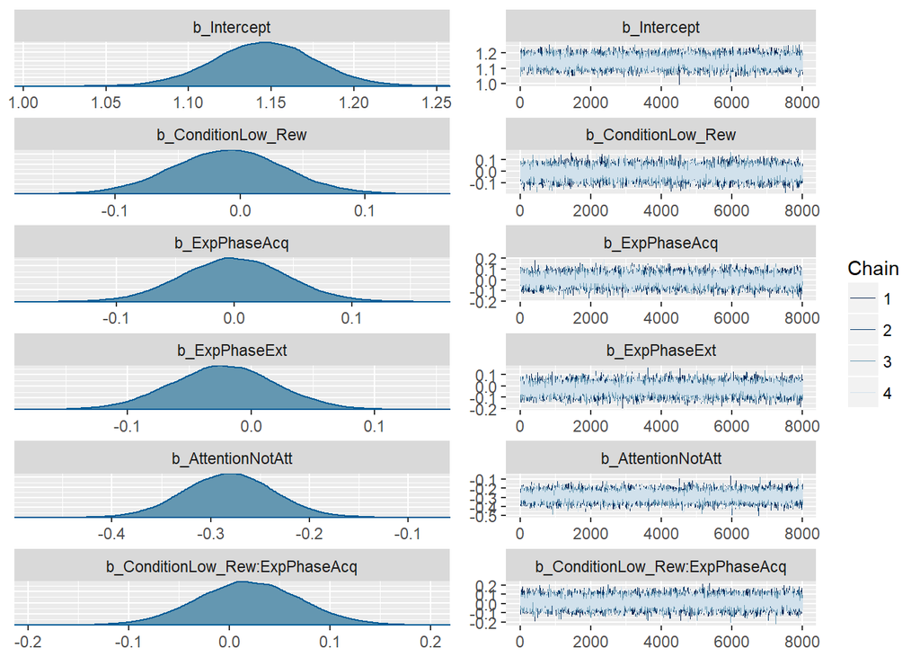

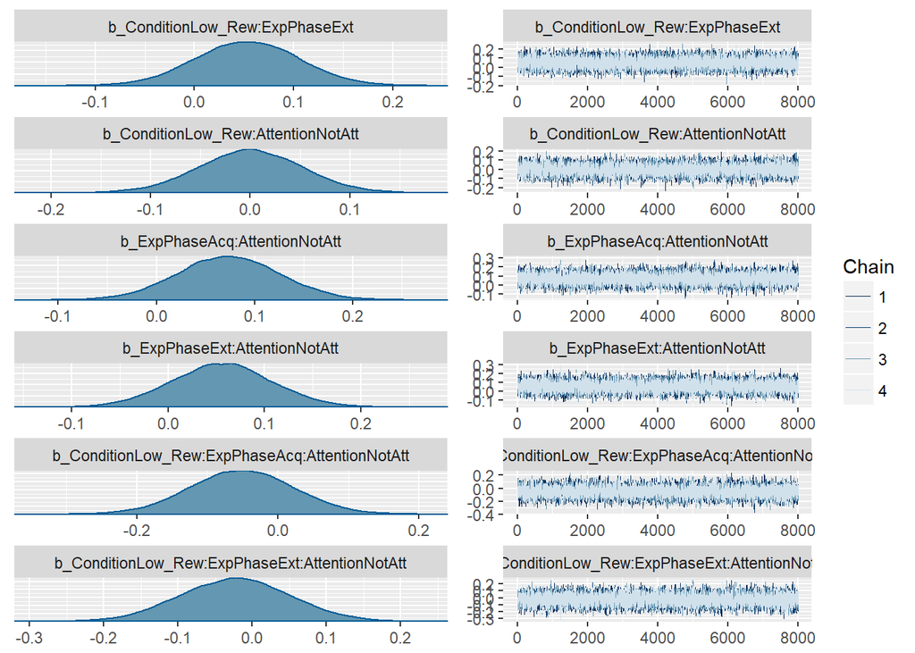

```r
# Plot chains
plot(model.full.threefactors, pars = "^b_", ask = FALSE, N=6)
```

Summary of the best model

```r
# Summary of the best model
print(tidy(model.full.threefactors, par_type = "non-varying"), digits = 1)
```

```
##                                            term estimate std.error lower
## 1                                     Intercept    1e+00      0.03  1.10
## 2                              ConditionLow_Rew   -1e-02      0.04 -0.08
## 3                                   ExpPhaseAcq    9e-05      0.04 -0.07
## 4                                   ExpPhaseExt   -2e-02      0.04 -0.09
## 5                               AttentionNotAtt   -3e-01      0.05 -0.36
## 6                  ConditionLow_Rew:ExpPhaseAcq    2e-02      0.05 -0.07
## 7                  ConditionLow_Rew:ExpPhaseExt    5e-02      0.05 -0.03
## 8              ConditionLow_Rew:AttentionNotAtt   -8e-07      0.05 -0.09
## 9                   ExpPhaseAcq:AttentionNotAtt    7e-02      0.05 -0.01
## 10                  ExpPhaseExt:AttentionNotAtt    6e-02      0.05 -0.03
## 11 ConditionLow_Rew:ExpPhaseAcq:AttentionNotAtt   -5e-02      0.07 -0.17
## 12 ConditionLow_Rew:ExpPhaseExt:AttentionNotAtt   -2e-02      0.07 -0.14
##    upper
## 1   1.20
## 2   0.06
## 3   0.07
## 4   0.05
## 5  -0.21
## 6   0.10
## 7   0.14
## 8   0.09
## 9   0.16
## 10  0.14
## 11  0.07
## 12  0.10
```

### Plotting the best model

```r
post = posterior_samples(model.full.threefactors, "^b")

# Calculate posteriors for each condition

################################################ Baseline ####

##################### Attended

######### High reward
Baseline_High_Attended = post[["b_Intercept"]]
######### Low reward
Baseline_Low_Attended = post[["b_Intercept"]] +
  post[["b_ConditionLow_Rew"]]

##################### Not Attended

######### High reward
Baseline_High_NotAttended = post[["b_Intercept"]] +
  post[["b_AttentionNotAtt"]]
######### Low reward
Baseline_Low_NotAttended = post[["b_Intercept"]] +
  post[["b_AttentionNotAtt"]] +
  post[["b_ConditionLow_Rew"]] +
  post[["b_ConditionLow_Rew:AttentionNotAtt"]]

################################################ Acquistion

##################### Attended

######### High reward
Acquisition_High_Attended = post[["b_Intercept"]] +
  post[["b_ExpPhaseAcq"]]
######### Low reward
Acquisition_Low_Attended = post[["b_Intercept"]] +
  post[["b_ExpPhaseAcq"]] +
  post[["b_ConditionLow_Rew"]] +
  post[["b_ConditionLow_Rew:ExpPhaseAcq"]]

##################### Not Attended

######### High reward
Acquisition_High_NotAttended = post[["b_Intercept"]] +
  post[["b_ExpPhaseAcq"]] +
  post[["b_AttentionNotAtt"]] +
  post[["b_ExpPhaseAcq:AttentionNotAtt"]]

######### Low reward
Acquisition_Low_NotAttended = post[["b_Intercept"]] +
  post[["b_ExpPhaseAcq"]] +
  post[["b_AttentionNotAtt"]] +
  post[["b_ConditionLow_Rew"]] +
  post[["b_ExpPhaseAcq:AttentionNotAtt"]] +
  post[["b_ConditionLow_Rew:ExpPhaseAcq"]] +
  post[["b_ConditionLow_Rew:ExpPhaseAcq:AttentionNotAtt"]]

################################################ Extinction

##################### Attended

######### High reward
Extinction_High_Attended = post[["b_Intercept"]] +
  post[["b_ExpPhaseExt"]]
######### Low reward
Extinction_Low_Attended = post[["b_Intercept"]] +
  post[["b_ExpPhaseExt"]] +
  post[["b_ConditionLow_Rew"]] +
  post[["b_ConditionLow_Rew:ExpPhaseExt"]]

##################### Not Attended

######### High reward
Extinction_High_NotAttended = post[["b_Intercept"]] +
  post[["b_ExpPhaseExt"]] +
  post[["b_AttentionNotAtt"]] +
  post[["b_ExpPhaseExt:AttentionNotAtt"]]
######### Low reward
Extinction_Low_NotAttended = post[["b_Intercept"]] +
  post[["b_ExpPhaseExt"]] +
  post[["b_AttentionNotAtt"]] +
  post[["b_ConditionLow_Rew"]] +
  post[["b_ExpPhaseExt:AttentionNotAtt"]] +
  post[["b_ConditionLow_Rew:ExpPhaseExt"]] +
  post[["b_ConditionLow_Rew:ExpPhaseExt:AttentionNotAtt"]]
```

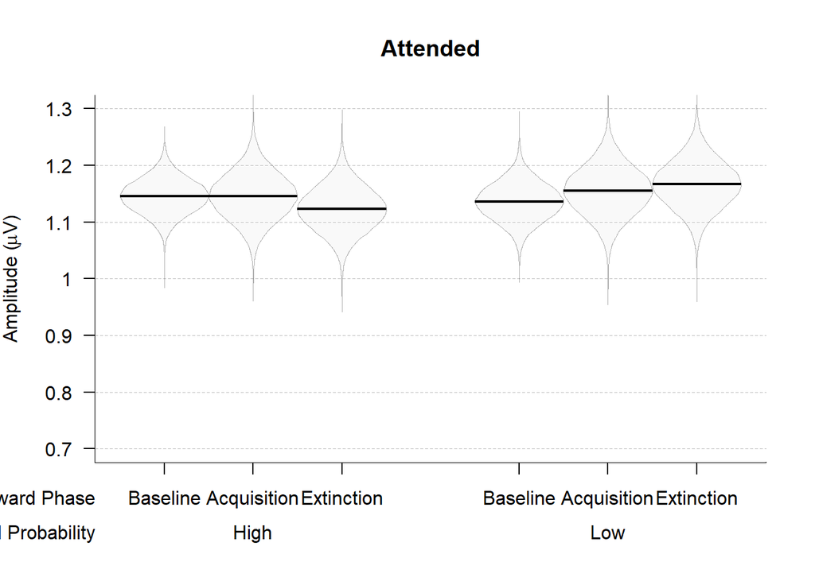

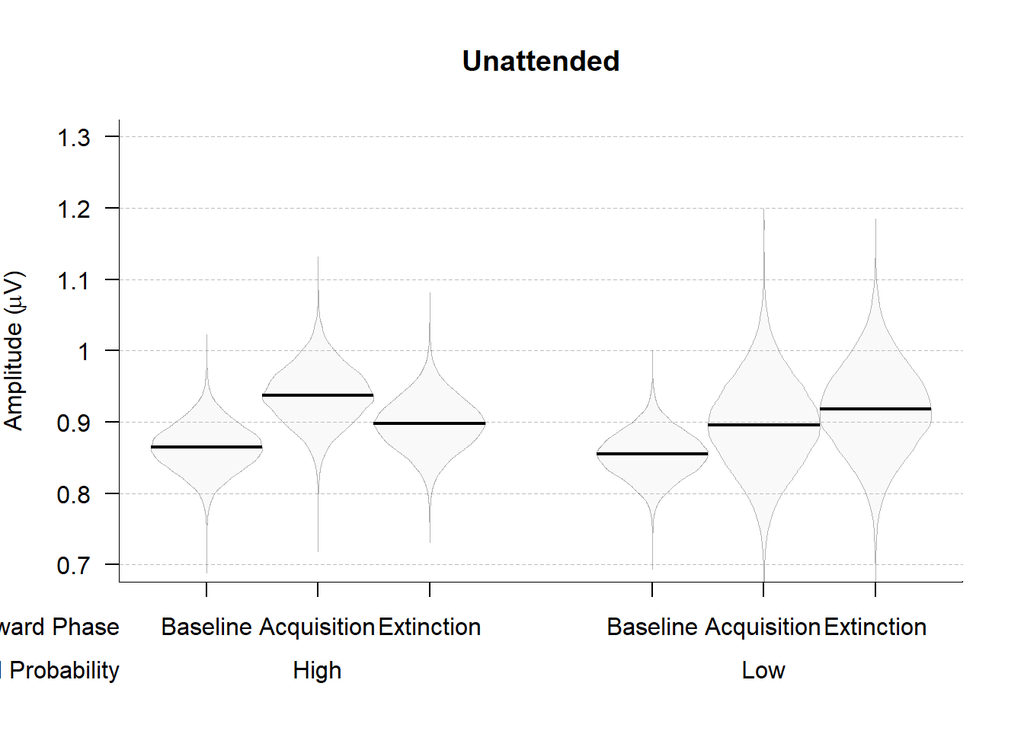

```r
# make a data frame

posterior_conditions = melt(data.frame(Baseline_High_Attended, Baseline_High_NotAttended, Baseline_Low_Attended, Baseline_Low_NotAttended, Acquisition_High_Attended, Acquisition_High_NotAttended, Acquisition_Low_Attended, Acquisition_Low_NotAttended, Extinction_High_Attended, Extinction_High_NotAttended, Extinction_Low_Attended, Extinction_Low_NotAttended))

posterior_conditions =  posterior_conditions %>% separate(variable, c("Reward Phase", "Reward Probability", "Attention"), "_", extra = "merge")

posterior_conditions$Attention = recode(posterior_conditions$Attention,
                           "Attended" = "Attended",
                           "NotAttended" = "Unattended")

names(posterior_conditions)[4] = "Amplitude"


#order
#dataPlot$`Reward phase` = factor(dataPlot$`Reward phase`, levels = c("Baseline","Acquisition","Extinction"))
#dataPlot = dataPlot[order(dataPlot$Attention,dataPlot$`Reward phase`,dataPlot$`Reward probability`),]


plottingConditions = c("Attended","Unattended" )
for (i in 1:length(plottingConditions)){

  if(plottingConditions[i]=="Attended"){dataAmplitudePlot=subset(posterior_conditions,Attention=="Attended")}

  if(plottingConditions[i]=="Unattended"){dataAmplitudePlot=subset(posterior_conditions,Attention=="Unattended")}

# Pirate plot

    pirateplot(formula = Amplitude ~ `Reward Phase` + `Reward Probability`, # dependent~independent variables
             data=dataAmplitudePlot, # data frame
             main=plottingConditions[i], # main title
             ylim=c(0.7,1.3), # y-axis: limits
             ylab=expression(paste("Amplitude (",mu,"V)")), # y-axis: label
             theme=0, # preset theme (0: use your own)
             avg.line.col="black", # average line: color
             avg.line.lwd=2, # average line: line width
             avg.line.o=1, # average line: opacity (0-1)
             bean.b.col="black", # bean border, color
             bean.lwd=0.6, # bean border, line width
             bean.lty=1, # bean border, line type (1: solid; 2:dashed; 3: dotted; ...)
             bean.b.o=0.3, # bean border, opacity (0-1)
             bean.f.col="gray", # bean filling, color
             bean.f.o=.1, # bean filling, opacity (0-1)
             cap.beans=FALSE, # max and min values of bean densities are capped at the limits found in the data
             gl.col="gray", # gridlines: color
             gl.lty=2, # gridlines: line type (1: solid; 2:dashed; 3: dotted; ...)
             cex.lab=1, # axis labels: size
             cex.axis=1, # axis numbers: size
             cex.names = 1,
             sortx = "sequential",
             bty="l", # plot box type
             back.col="white") # background, color
}
```

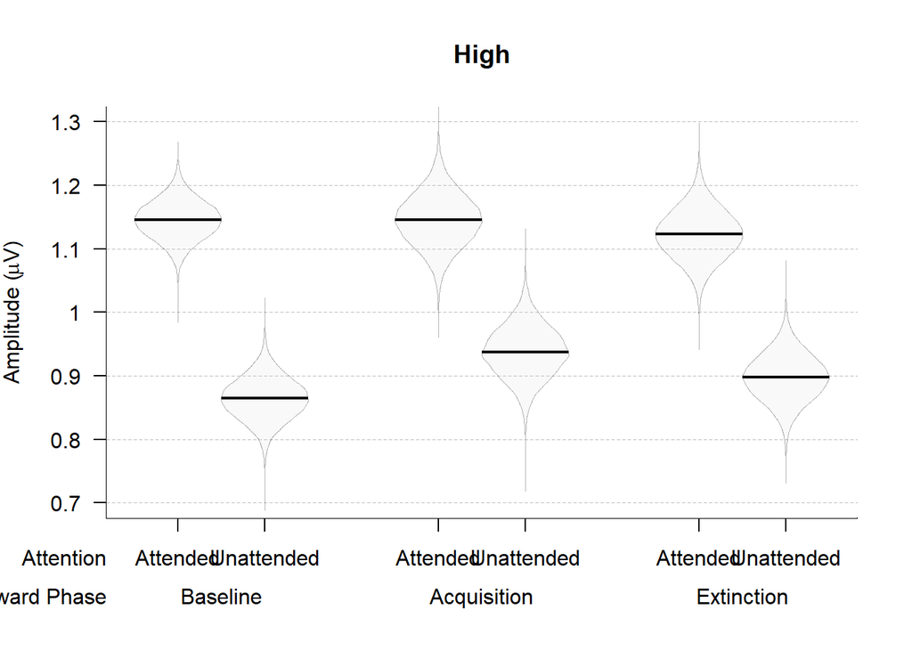

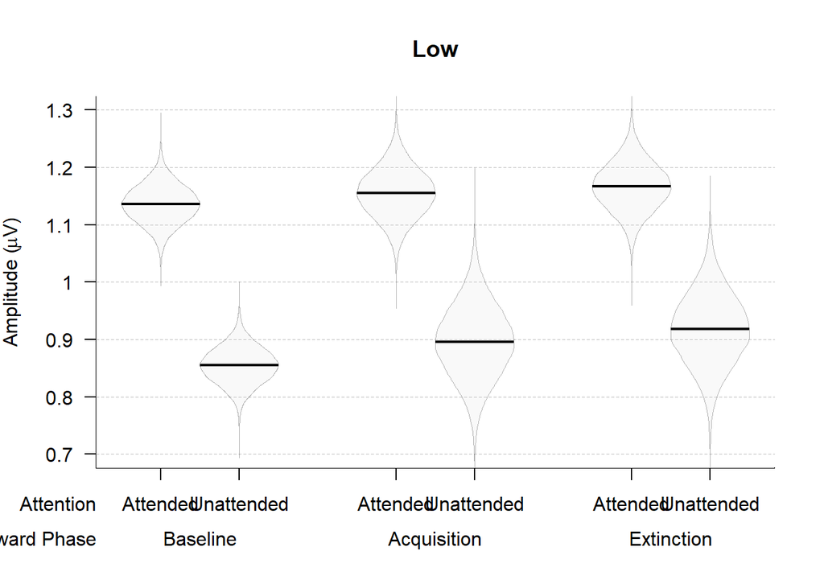

```r
plottingConditions = c("High","Low" )
for (i in 1:length(plottingConditions)){

  if(plottingConditions[i]=="High"){dataAmplitudePlot=subset(posterior_conditions,`Reward Probability`=="High")}

  if(plottingConditions[i]=="Low"){dataAmplitudePlot=subset(posterior_conditions,`Reward Probability`=="Low")}

# Pirate plot

    pirateplot(formula = Amplitude ~ `Attention` + `Reward Phase`, # dependent~independent variables
             data=dataAmplitudePlot, # data frame
             main=plottingConditions[i], # main title
             ylim=c(0.7,1.3), # y-axis: limits
             ylab=expression(paste("Amplitude (",mu,"V)")), # y-axis: label
             theme=0, # preset theme (0: use your own)
             avg.line.col="black", # average line: color
             avg.line.lwd=2, # average line: line width
             avg.line.o=1, # average line: opacity (0-1)
             bean.b.col="black", # bean border, color
             bean.lwd=0.6, # bean border, line width
             bean.lty=1, # bean border, line type (1: solid; 2:dashed; 3: dotted; ...)
             bean.b.o=0.3, # bean border, opacity (0-1)
             bean.f.col="gray", # bean filling, color
             bean.f.o=.1, # bean filling, opacity (0-1)
             cap.beans=FALSE, # max and min values of bean densities are capped at the limits found in the data
             gl.col="gray", # gridlines: color
             gl.lty=2, # gridlines: line type (1: solid; 2:dashed; 3: dotted; ...)
             cex.lab=1, # axis labels: size
             cex.axis=1, # axis numbers: size
             cex.names = 1,
             sortx = "sequential",
             bty="l", # plot box type
             back.col="white") # background, color
}
```

Table of means across conditions

```r
# Make a table with conditions
posterior_means = as.data.frame(c("Attended Baseline High Reward",
                                  "Attended Baseline Low Reward",
                                  "Attended Acquisition High Reward",
                                  "Attended Acquisition Low Reward",
                                  "Attended Extinction High Reward",
                                  "Attended Extinction Low Reward",
                                  "Unattended Baseline High Reward",
                                  "Unattended Baseline Low Reward",
                                  "Unattended Acquisition High Reward",
                                  "Unattended Acquisition Low Reward",
                                  "Unattended Extinction High Reward",
                                  "Unattended Extinction Low Reward"))
names(posterior_means)[1] = "Condition"

posterior_means$Mean = c(paste(round(mean(Baseline_High_Attended), digits = 2), " [", round(hdi(Baseline_High_Attended)[[1]], digits = 2), " ", round(hdi(Baseline_High_Attended)[[2]], digits = 2), "]"),
                        paste(round(mean(Baseline_Low_Attended), digits = 2), " [", round(hdi(Baseline_Low_Attended)[[1]], digits = 2), " ", round(hdi(Baseline_Low_Attended)[[2]], digits = 2), "]"),

                        paste(round(mean(Acquisition_High_Attended), digits = 2), " [", round(hdi(Acquisition_High_Attended)[[1]], digits = 2), " ", round(hdi(Acquisition_High_Attended)[[2]], digits = 2), "]"),
                        paste(round(mean(Acquisition_Low_Attended), digits = 2), " [", round(hdi(Acquisition_Low_Attended)[[1]], digits = 2), " ", round(hdi(Acquisition_Low_Attended)[[2]], digits = 2), "]"),
                        paste(round(mean(Extinction_High_Attended), digits = 2), " [", round(hdi(Extinction_High_Attended)[[1]], digits = 2), " ", round(hdi(Extinction_High_Attended)[[2]], digits = 2), "]"),
                        paste(round(mean(Extinction_Low_NotAttended), digits = 2), " [", round(hdi(Extinction_Low_NotAttended)[[1]], digits = 2), " ", round(hdi(Extinction_Low_NotAttended)[[2]], digits = 2), "]"),
                        paste(round(mean(Baseline_High_NotAttended), digits = 2), " [", round(hdi(Baseline_High_NotAttended)[[1]], digits = 2), " ", round(hdi(Baseline_High_NotAttended)[[2]], digits = 2), "]"),
                        paste(round(mean(Baseline_Low_NotAttended), digits = 2), " [", round(hdi(Baseline_Low_NotAttended)[[1]], digits = 2), " ", round(hdi(Baseline_Low_NotAttended)[[2]], digits = 2), "]"),
                        paste(round(mean(Acquisition_High_NotAttended), digits = 2), " [", round(hdi(Acquisition_High_NotAttended)[[1]], digits = 2), " ", round(hdi(Acquisition_High_NotAttended)[[2]], digits = 2), "]"),
                        paste(round(mean(Acquisition_Low_NotAttended), digits = 2), " [", round(hdi(Acquisition_Low_NotAttended)[[1]], digits = 2), " ", round(hdi(Acquisition_Low_NotAttended)[[2]], digits = 2), "]"),
                        paste(round(mean(Extinction_High_NotAttended), digits = 2), " [", round(hdi(Extinction_High_NotAttended)[[1]], digits = 2), " ", round(hdi(Extinction_High_NotAttended)[[2]], digits = 2), "]"),
                        paste(round(mean(Extinction_Low_NotAttended), digits = 2), " [", round(hdi(Extinction_Low_NotAttended)[[1]], digits = 2), " ", round(hdi(Extinction_Low_NotAttended)[[2]], digits = 2), "]"))

names(posterior_means)[2] = "Mean [HDI]"

posterior_means =  posterior_means %>% separate(Condition, c("Attention", "Reward Phase", "Reward Probability"), " ", extra = "merge")

kable(posterior_means, caption = "Means per condition")
```

Means per condition

[output not shown]

#### Attended vs. unattended

Check the difference between attended and not attended in baseline high rewarded

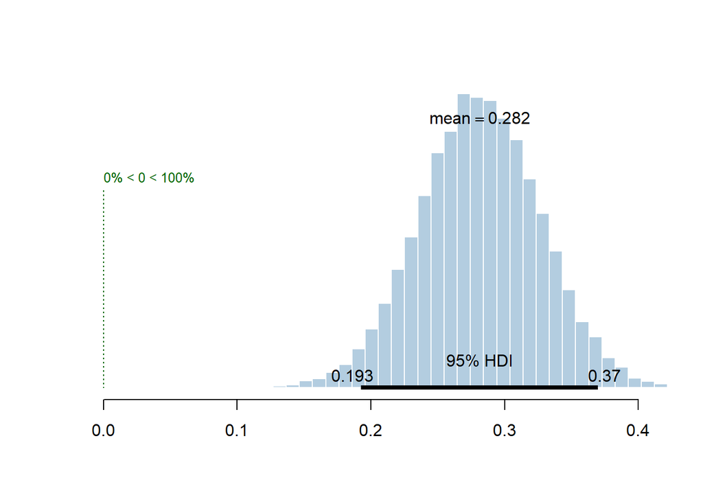

```r
Diff_Att_NotAtt_Bsln_High = Baseline_High_Attended - Baseline_High_NotAttended
plotPost(Diff_Att_NotAtt_Bsln_High, xlab = "", col = "#b3cde0", cex = 1, showCurve = FALSE, compVal = 0)
```

Check the difference between attended and not attended in baseline low rewarded

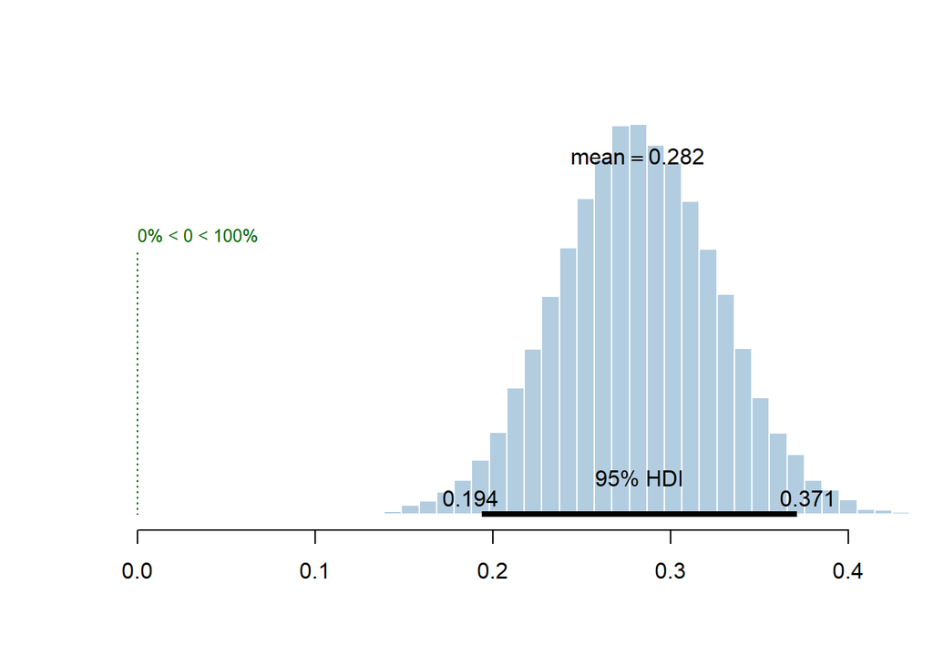

```r
Diff_Att_NotAtt_Bsln_Low = Baseline_Low_Attended - Baseline_Low_NotAttended
plotPost(Diff_Att_NotAtt_Bsln_Low, xlab = "", col = "#b3cde0", cex = 1, showCurve = FALSE, compVal = 0)
```

Check the difference between attended and not attended in acquisition high rewarded

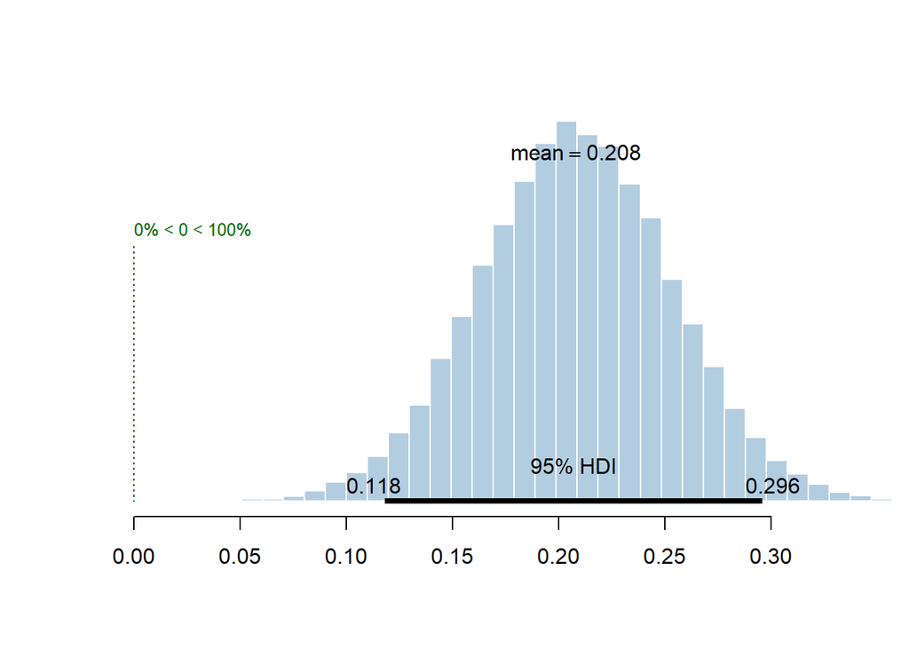

```r
Diff_Att_NotAtt_Acq_High = Acquisition_High_Attended - Acquisition_High_NotAttended
plotPost(Diff_Att_NotAtt_Acq_High, xlab = "", col = "#b3cde0", cex = 1, showCurve = FALSE, compVal = 0)
```

Check the difference between attended and not attended in acquisition low rewarded

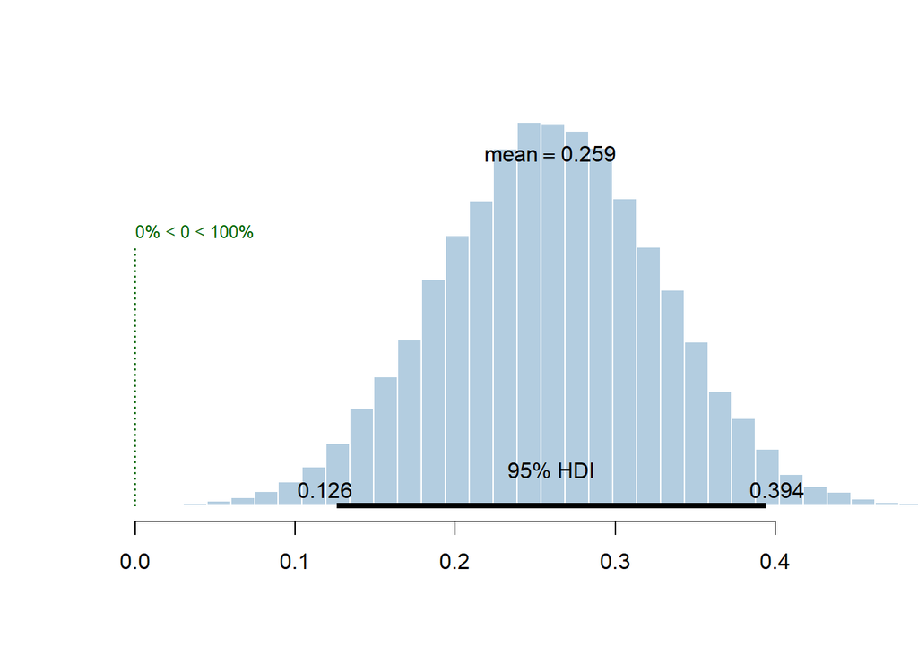

```r
Diff_Att_NotAtt_Acq_Low = Acquisition_Low_Attended - Acquisition_Low_NotAttended
plotPost(Diff_Att_NotAtt_Acq_Low, xlab = "", col = "#b3cde0", cex = 1, showCurve = FALSE, compVal = 0)
```

Check the difference between attended and not attended in extinction high rewarded

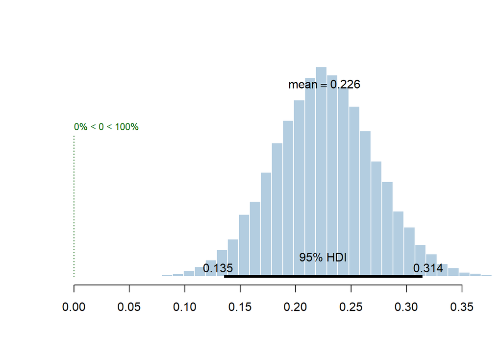

```r
Diff_Att_NotAtt_Ext_High = Extinction_High_Attended - Extinction_High_NotAttended
plotPost(Diff_Att_NotAtt_Ext_High, xlab = "", col = "#b3cde0", cex = 1, showCurve = FALSE, compVal = 0)
```

Check the difference between attended and not attended in extinction low rewarded

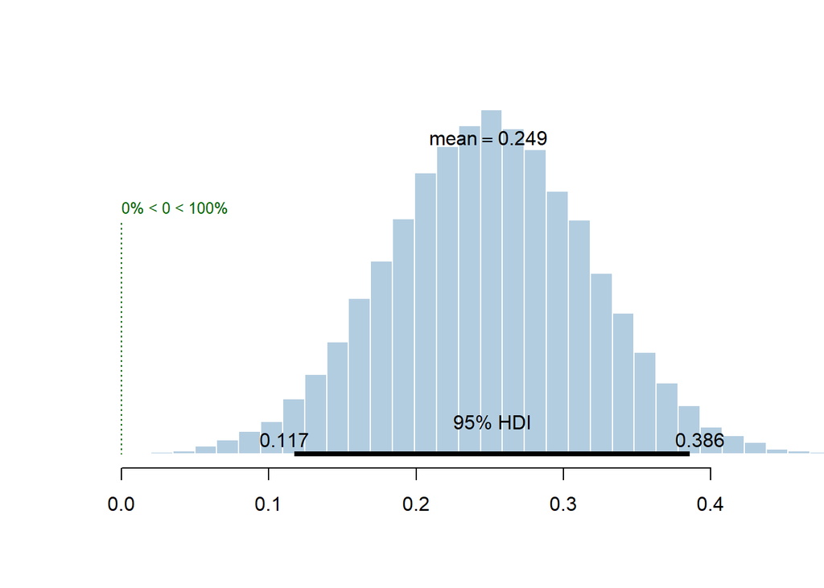

```r
Diff_Att_NotAtt_Ext_Low = Extinction_Low_Attended - Extinction_Low_NotAttended
plotPost(Diff_Att_NotAtt_Ext_Low, xlab = "", col = "#b3cde0", cex = 1, showCurve = FALSE, compVal = 0)
```

#### Comparison between phases

Check the difference between baseline and acquisition in high reward attended

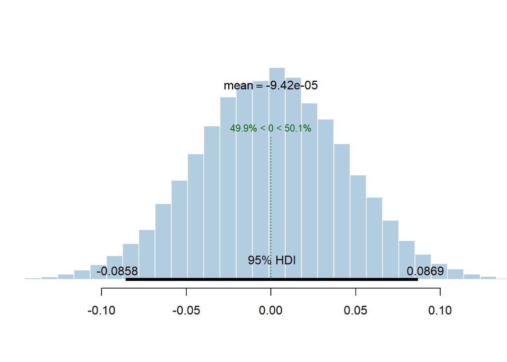

```r
Diff_Bsln_Acq_High_Att = Baseline_High_Attended - Acquisition_High_Attended
plotPost(Diff_Bsln_Acq_High_Att, xlab = "", col = "#b3cde0", cex = 1, showCurve = FALSE, compVal = 0)
```

Check the difference between baseline and acquisition in low reward attended

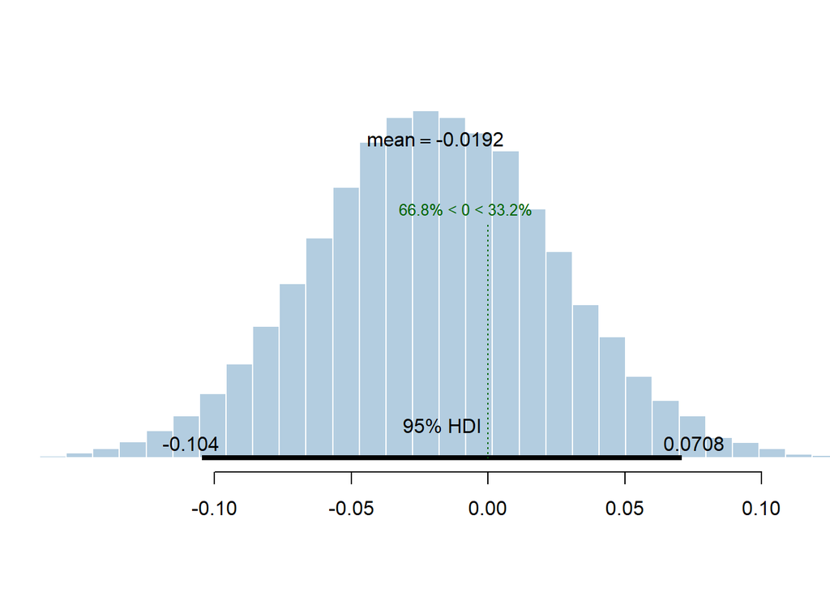

```r
Diff_Bsln_Acq_Low_Att = Baseline_Low_Attended - Acquisition_Low_Attended
plotPost(Diff_Bsln_Acq_Low_Att, xlab = "", col = "#b3cde0", cex = 1, showCurve = FALSE, compVal = 0)
```

Check the difference between baseline and acquisition in high reward not attended

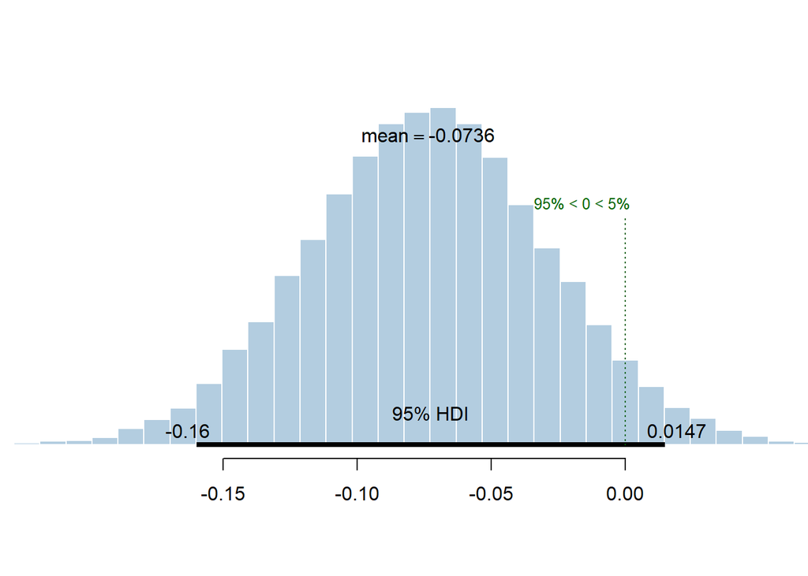

```r
Diff_Bsln_Acq_High_NotAtt = Baseline_High_NotAttended - Acquisition_High_NotAttended
plotPost(Diff_Bsln_Acq_High_NotAtt, xlab = "", col = "#b3cde0", cex = 1, showCurve = FALSE, compVal = 0)
```

Check the difference between baseline and acquisition in low reward not attended

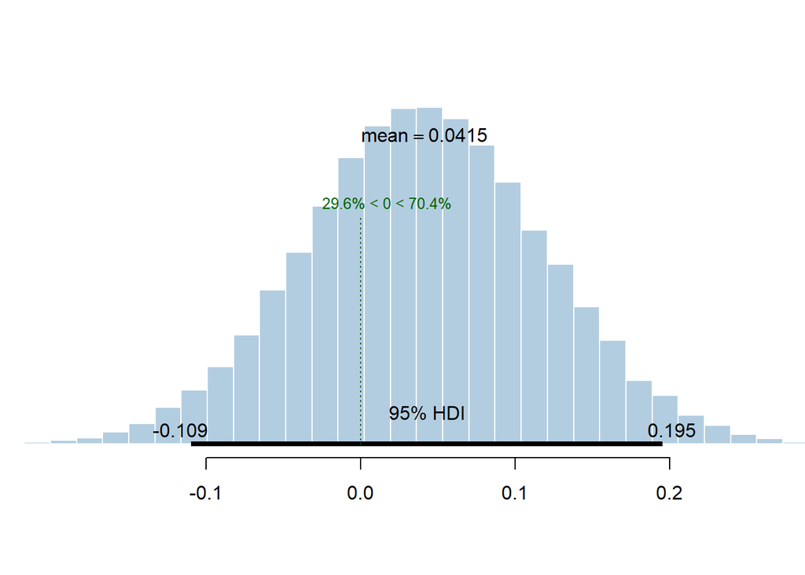

```r
Diff_Bsln_Acq_Low_NotAtt = Acquisition_Low_NotAttended - Baseline_Low_NotAttended
plotPost(Diff_Bsln_Acq_Low_NotAtt, xlab = "", col = "#b3cde0", cex = 1, showCurve = FALSE, compVal = 0)
```

Check the difference between acquisition and extinction in high reward attended

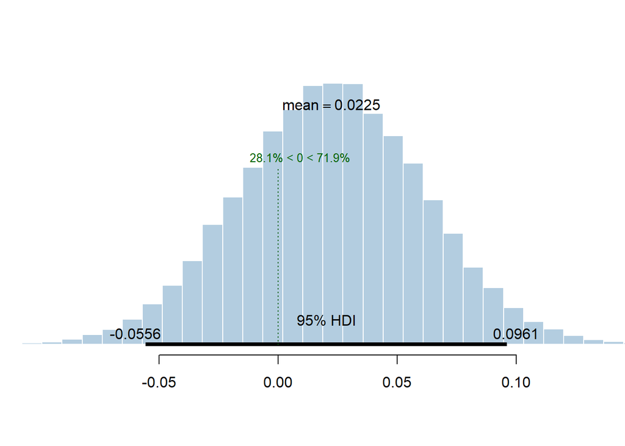

```r
Diff_Acq_Ext_High_Att = Acquisition_High_Attended - Extinction_High_Attended
plotPost(Diff_Acq_Ext_High_Att, xlab = "", col = "#b3cde0", cex = 1, showCurve = FALSE, compVal = 0)
```

Check the difference between acquisition and extinction in low reward attended

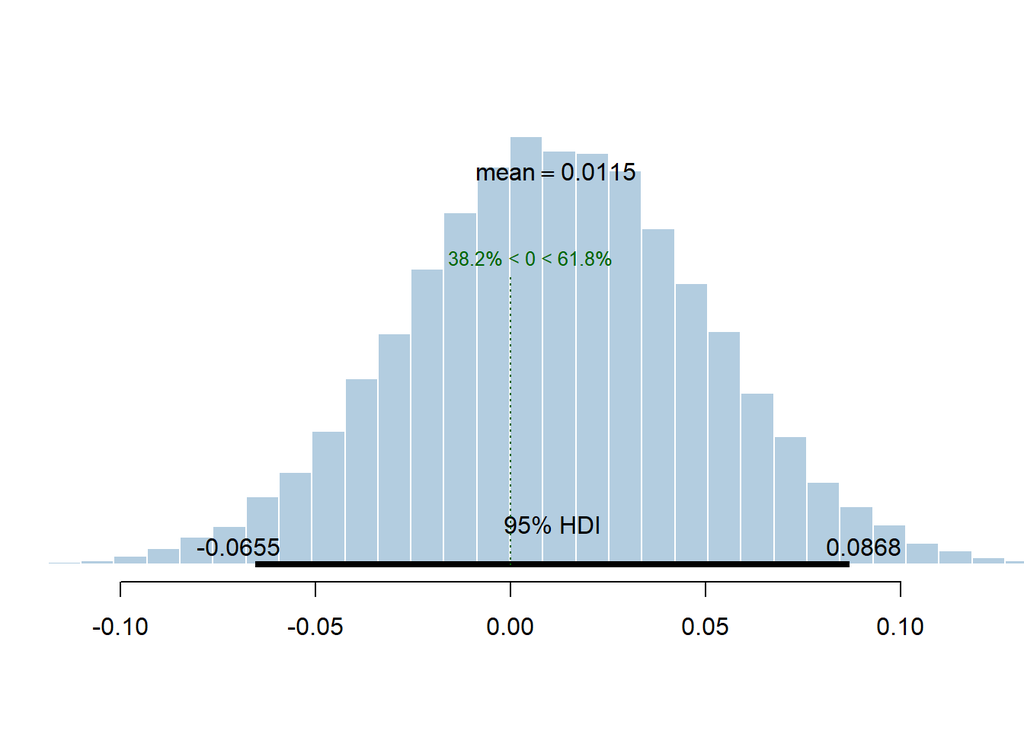

```r
Diff_Acq_Ext_Low_Att = Extinction_Low_Attended - Acquisition_Low_Attended
plotPost(Diff_Acq_Ext_Low_Att, xlab = "", col = "#b3cde0", cex = 1, showCurve = FALSE, compVal = 0)
```

Check the difference between acquisition and extinction in high reward not attended

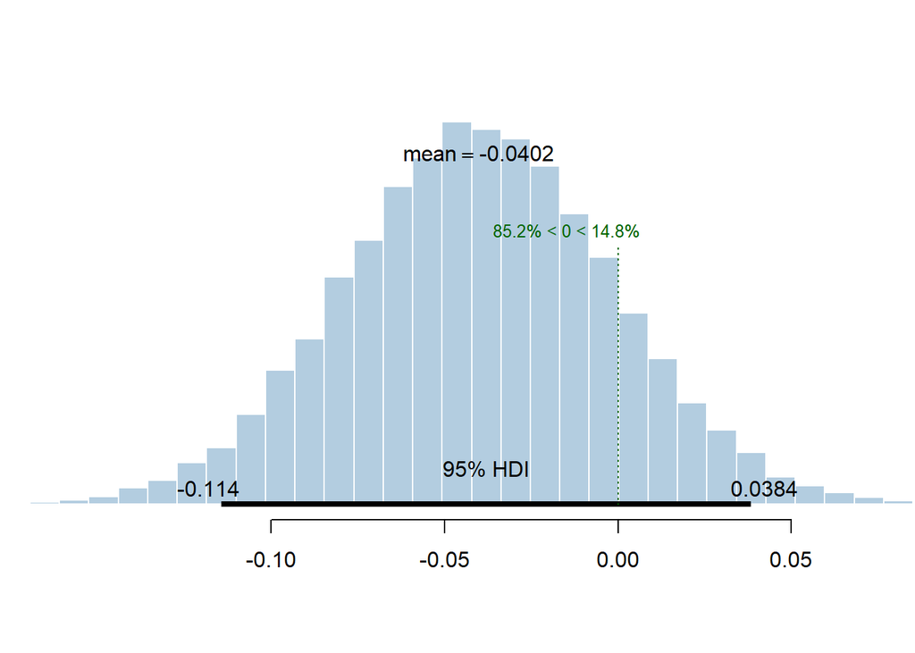

```r
Diff_Acq_Ext_High_NotAtt = Extinction_High_NotAttended - Acquisition_High_NotAttended
plotPost(Diff_Acq_Ext_High_NotAtt, xlab = "", col = "#b3cde0", cex = 1, showCurve = FALSE, compVal = 0)
```

Check the difference between acquisition and extinction in low reward not attended

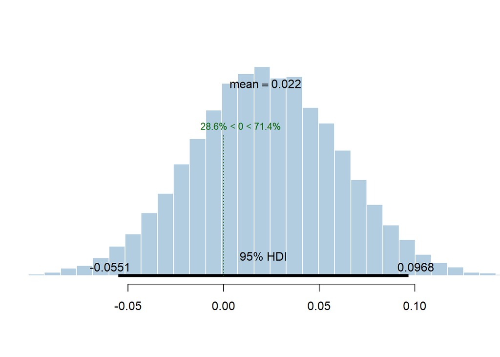

```r
Diff_Acq_Ext_Low_NotAtt = Extinction_Low_NotAttended - Acquisition_Low_NotAttended
plotPost(Diff_Acq_Ext_Low_NotAtt, xlab = "", col = "#b3cde0", cex = 1, showCurve = FALSE, compVal = 0)
```

#### Baseline difference

Check the difference between high and low reward in baseline attended

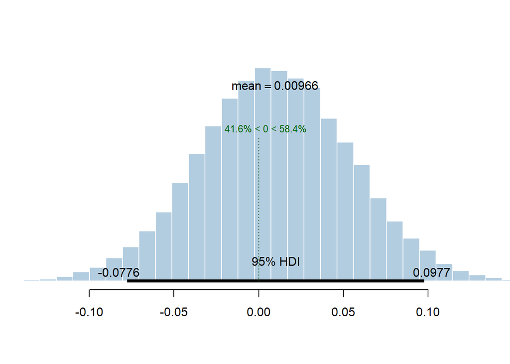

```r
Diff_Bsln_High_Low_Att = Baseline_High_Attended - Baseline_Low_Attended
plotPost(Diff_Bsln_High_Low_Att, xlab = "", col = "#b3cde0", cex = 1, showCurve = FALSE, compVal = 0)
```

Check the difference between high and low reward in baseline not attended

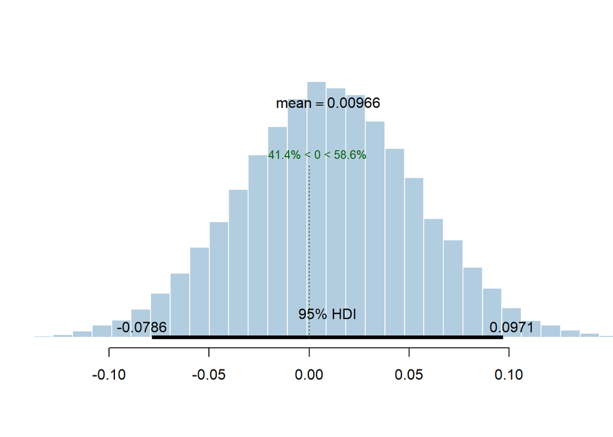

```r
Diff_Bsln_High_Low_NotAtt = Baseline_High_NotAttended - Baseline_Low_NotAttended
plotPost(Diff_Bsln_High_Low_NotAtt, xlab = "", col = "#b3cde0", cex = 1, showCurve = FALSE, compVal = 0)
```

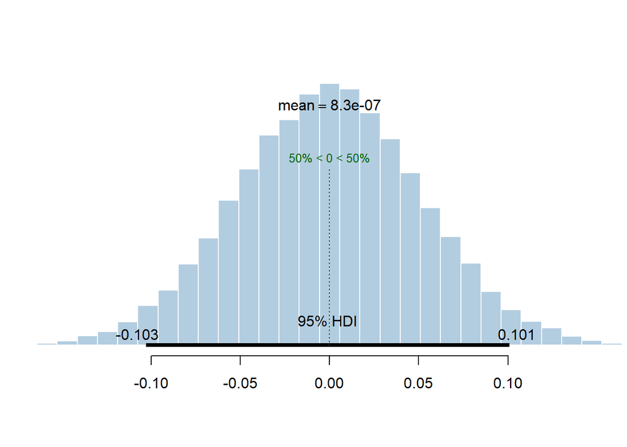

```r
Diff_Bsln_Acq_High_vs_Low_in_attended_vs_unattended = Diff_Bsln_High_Low_NotAtt - Diff_Bsln_High_Low_Att
plotPost(Diff_Bsln_Acq_High_vs_Low_in_attended_vs_unattended, xlab = "", col = "#b3cde0", showCurve = FALSE, cex = 1, compVal = 0)
```

```r
paste("Mean = ",round(mean(Diff_Bsln_Acq_High_vs_Low_in_attended_vs_unattended), digits = 2), " [", round(hdi(Diff_Bsln_Acq_High_vs_Low_in_attended_vs_unattended)[[1]], digits = 2), " ", round(hdi(Diff_Bsln_Acq_High_vs_Low_in_attended_vs_unattended)[[2]], digits = 2), "]")
```

```
## [1] "Mean =  0  [ -0.1   0.1 ]"
```